# Overfitting, crossvalidation, and sparsification

Peter Ralph

26 January 2021 – Advanced Biological Statistics

# Prediction

## Out-of-sample prediction

To test predictive ability (and diagnose overfitting!):

1. Split the data into *test* and *training* pieces.
2. Fit the model using the training data.
3. See how well it predicts the test data.

If you do this a lot of times, it’s called *crossvalidation*.

[figure not shown]

is it Christmas? No. (99.73% accurate)

https://xkcd.com/2236/

# Overfitting: when you have too much information

## Example data

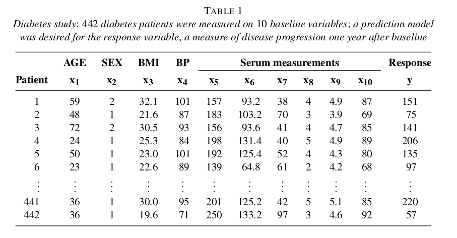

from Efron, Hastie, Johnstone, & Tibshirani

```r
library(lars)
data(diabetes)
class(diabetes$x2) <- "matrix"
```

[output not shown]

The dataset has

- 442 diabetes patients
- 10 main variables: age, gender, body mass index, average blood pressure (map), and six blood serum measurements (tc, ldl, hdl, tch, ltg, glu)
- 45 interactions, e.g. `age:ldl`
- 9 quadratic effects, e.g. `age^2`
- measure of disease progression taken one year later: `y`

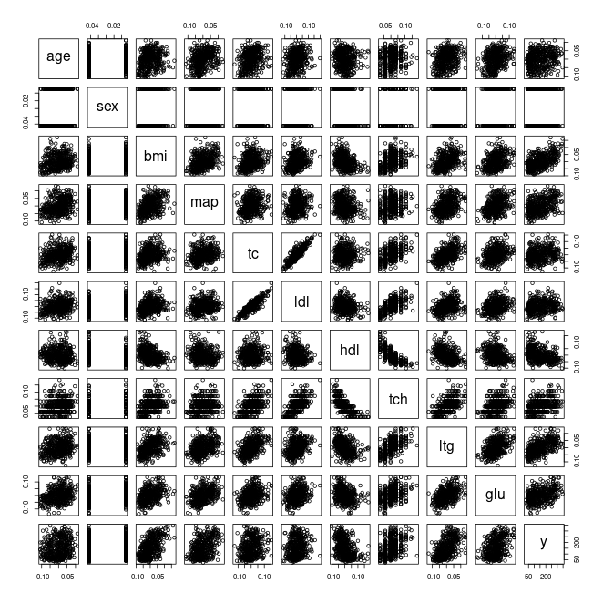

```r
cor(cbind(diabetes$x, y=diabetes$y))
```

```
##        age    sex    bmi   map    tc   ldl    hdl   tch   ltg   glu      y
## age  1.000  0.174  0.185  0.34 0.260  0.22 -0.075  0.20  0.27  0.30  0.188
## sex  0.174  1.000  0.088  0.24 0.035  0.14 -0.379  0.33  0.15  0.21  0.043
## bmi  0.185  0.088  1.000  0.40 0.250  0.26 -0.367  0.41  0.45  0.39  0.586
## map  0.335  0.241  0.395  1.00 0.242  0.19 -0.179  0.26  0.39  0.39  0.441
## tc   0.260  0.035  0.250  0.24 1.000  0.90  0.052  0.54  0.52  0.33  0.212
## ldl  0.219  0.143  0.261  0.19 0.897  1.00 -0.196  0.66  0.32  0.29  0.174
## hdl -0.075 -0.379 -0.367 -0.18 0.052 -0.20  1.000 -0.74 -0.40 -0.27 -0.395
## tch  0.204  0.332  0.414  0.26 0.542  0.66 -0.738  1.00  0.62  0.42  0.430
## ltg  0.271  0.150  0.446  0.39 0.516  0.32 -0.399  0.62  1.00  0.46  0.566
## glu  0.302  0.208  0.389  0.39 0.326  0.29 -0.274  0.42  0.46  1.00  0.382
## y    0.188  0.043  0.586  0.44 0.212  0.17 -0.395  0.43  0.57  0.38  1.000
```

## Crossvalidation plan

1. Put aside 20% of the data for *testing*.
2. Refit the model.
3. Predict the test data; compute
   $$\begin{aligned}
   S = \sqrt{\frac{1}{M} \sum_{k=1}^M (\hat y_i - y_i)^2}
   \end{aligned}$$
4. Repeat for the other four 20%s.
5. Compare.

## Crossvalidation

First let’s split the data into testing and training just once:

```r
test_observations <- (rbinom(nrow(diabetes), size=1, prob=0.2) == 1)
test_d <- cbind(data.frame(y=diabetes$y[test_observations]),
                diabetes$x2[test_observations,])
training_d <- cbind(data.frame(y=diabetes$y[!test_observations]),
                diabetes$x2[!test_observations,])
```

## Ordinary least squares

```r
ols <- lm(y ~ ., data=training_d)
summary(ols)
```

```
##
## Call:
## lm(formula = y ~ ., data = training_d)
##
## Residuals:
##     Min      1Q  Median      3Q     Max
## -149.52  -31.10   -1.21   29.00  147.31
##
## Coefficients:
##              Estimate Std. Error t value Pr(>|t|)
## (Intercept)    153.39       2.89   53.09  < 2e-16 ***
## age             68.06      74.61    0.91    0.362
## sex           -327.29      78.36   -4.18 0.000040 ***
## bmi            401.24      98.21    4.09 0.000058 ***
## map            423.92      84.82    5.00 0.000001 ***
## tc          -13659.91   78291.28   -0.17    0.862
## ldl          11966.61   68813.44    0.17    0.862
## hdl           4816.50   29265.52    0.16    0.869
## tch            -80.94     324.56   -0.25    0.803
## ltg           5192.60   25741.01    0.20    0.840
## glu             71.35      83.17    0.86    0.392
## `age^2`         79.90      78.24    1.02    0.308
## `bmi^2`         73.83      91.38    0.81    0.420
## `map^2`         37.13      81.21    0.46    0.648
## `tc^2`        6702.06    8693.93    0.77    0.441
## `ldl^2`       4819.05    6659.04    0.72    0.470
## `hdl^2`        577.56    1920.55    0.30    0.764
## `tch^2`        495.64     726.06    0.68    0.495
## `ltg^2`       2086.73    2194.66    0.95    0.343
## `glu^2`        140.25     109.37    1.28    0.201
## `age:sex`       94.23      82.12    1.15    0.252
## `age:bmi`       24.56      89.76    0.27    0.785
## `age:map`       -7.08      87.87   -0.08    0.936
## `age:tc`       158.54     690.02    0.23    0.818
## `age:ldl`     -364.79     554.99   -0.66    0.512
## `age:hdl`       81.67     318.90    0.26    0.798
## `age:tch`      148.36     233.76    0.63    0.526
## `age:ltg`       88.02     256.37    0.34    0.732
## `age:glu`       -7.31      91.64   -0.08    0.937
## `sex:bmi`       57.41      88.76    0.65    0.518
```

[output cut: 26 more lines]

```
## `ldl:tch`      471.69    1725.54    0.27    0.785
## `ldl:ltg`     2009.36   14123.54    0.14    0.887
## `ldl:glu`      139.56     641.01    0.22    0.828
## `hdl:tch`      390.83    1195.72    0.33    0.744
## `hdl:ltg`      766.89    5898.00    0.13    0.897
## `hdl:glu`      277.75     350.76    0.79    0.429
## `tch:ltg`      116.53     713.76    0.16    0.870
## `tch:glu`      224.55     268.74    0.84    0.404
## `ltg:glu`      149.20     329.31    0.45    0.651
## ---
## Signif. codes:  0 '***' 0.001 '**' 0.01 '*' 0.05 '.' 0.1 ' ' 1
##
## Residual standard error: 52 on 277 degrees of freedom
## Multiple R-squared:  0.619,  Adjusted R-squared:  0.531
## F-statistic: 7.04 on 64 and 277 DF,  p-value: <2e-16
```

```r
ols_pred <- predict(ols, newdata=test_d)
ols_mse <- sqrt(mean((ols_pred - test_d$y)^2))
c(train=sqrt(mean(resid(ols)^2)),
  test=ols_mse)
```

```
## train  test
##    47    61
```

With ordinary linear regression, we got a root-mean-square-prediction-error of 61.17 (on the *test* data), compared to a root-mean-square-error of 47.07 for the *training* data.

This suggests there’s some overfitting going on.

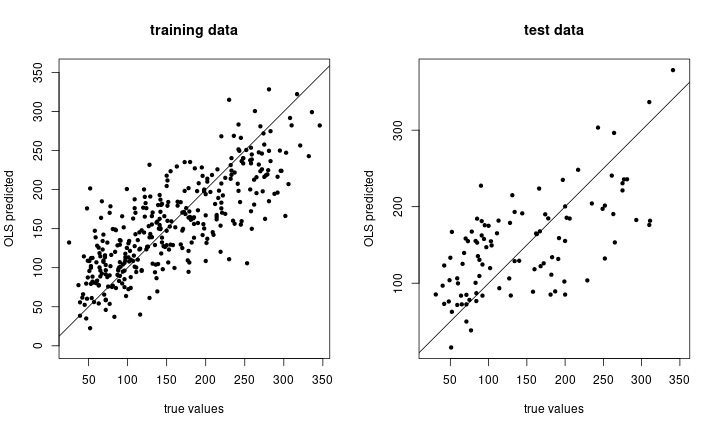

```r
plot(training_d$y, predict(ols), xlab="true values", ylab="OLS predicted", main="training data", pch=20, asp=1)
abline(0,1)
plot(test_d$y, ols_pred, xlab="true values", ylab="OLS predicted", main="test data", pch=20, asp=1)
abline(0,1)
```

## A sparsifying prior

We have a lot of predictors: 64 of them. A good guess is that only a few are really useful. So, we can put a *sparsifying* prior on the coefficients, i.e., $\beta$s in
$$\begin{aligned}
y = \beta_0 + \beta_1 x_1 + \cdots \beta_n x_n + \epsilon
\end{aligned}$$

# Overfitting: the effect of spurious variables

## Who says we don’t do experiments?

1. Simulate data with `y ~ a + b x[1] + c x[2]`, and fit a linear model.
2. Measure in-sample and out-of-sample prediction error.
3. Add spurious variables, and report the above as a function of number of variables.

## Basic data: $y = a + b_1 x_1 + b_2 x_2 + \epsilon$.

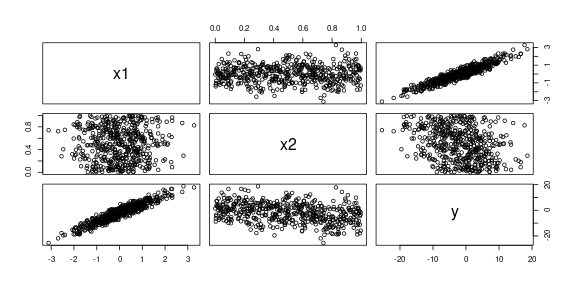

```r
N <- 500
df <- data.frame(x1 = rnorm(N),
                 x2 = runif(N))
params <- list(intercept = 2.0,
               x1 = 7.0,
               x2 = -8.0,
               sigma = 1)
pred_y <- params$intercept + params$x1 * df$x1 + params$x2 * df$x2
df$y <- rnorm(N, mean=pred_y, sd=params$sigma)
pairs(df)
```

## Crossvalidation error function

```r
kfold <- function (K, df) {
    Kfold <- sample(rep(1:K, nrow(df)/K))
    results <- data.frame(test_error=rep(NA, K), train_error=rep(NA, K))
    for (k in 1:K) {
        the_lm <- lm(y ~ ., data=df, subset=(Kfold != k))
        results$train_error[k] <- sqrt(mean(resid(the_lm)^2))
        test_y <- df$y[Kfold == k]
        results$test_error[k] <- sqrt(mean(
                       (test_y - predict(the_lm, newdata=subset(df, Kfold==k)))^2 ))
    }
    return(results)
}
```

## Add spurious variables

```r
max_M <- 300  # max number of spurious variables
noise_df <- matrix(rnorm(nrow(df) * (max_M-2)), nrow=nrow(df))
colnames(noise_df) <- paste0('z', 1:ncol(noise_df))
new_df <- cbind(df, noise_df)
all_results <- data.frame(m=floor(seq(from=2, to=max_M-1, length.out=40)),
                          test_error=NA, train_error=NA)
for (j in 1:nrow(all_results)) {
    m <- all_results$m[j]
    all_results[j,2:3] <- colMeans(kfold(K=10, new_df[,1:(m+1)]))
}
```

## Results

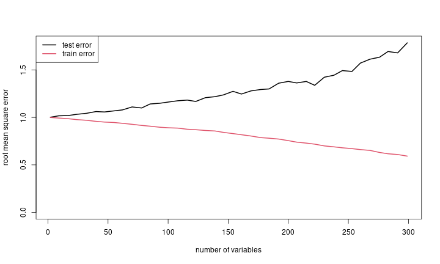

```r
plot(all_results$m, all_results$test_error, type='l', lwd=2,
     xlab='number of variables', ylab='root mean square error', ylim=range(all_results[,2:3], 0))
lines(all_results$m, all_results$train_error, col=2, lwd=2)
legend("topleft", lty=1, col=1:2, lwd=2, legend=paste(c("test", "train"), "error"))
```

# Interlude

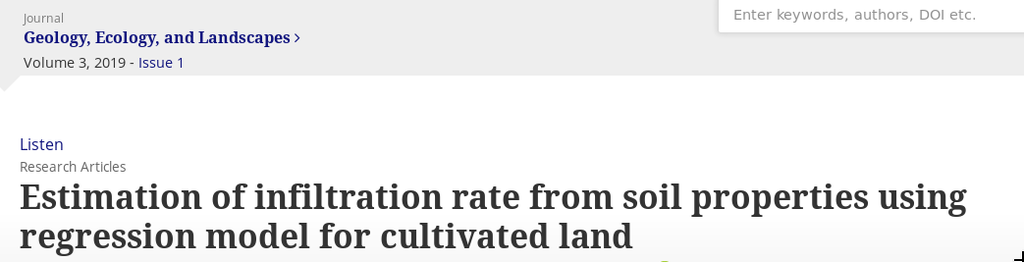

Estimation of infiltration rate from soil properties using regression model for cultivated land

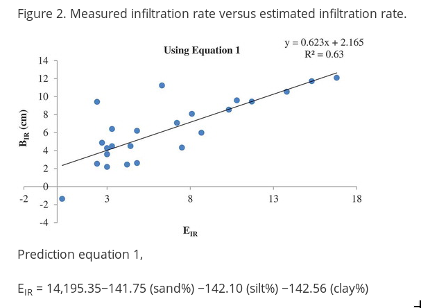

EIR = 14,195.35 - 141.75 (sand%) - 142.10 (silt%) - 142.56 (clay%)

Use the data to try to reproduce their model:

[output not shown]

They’re not wrong! What’s up with those coefficients, though?

# Sparseness and scale mixtures

## Encouraging sparseness

Suppose we do regression with a *large* number of predictor variables.

The resulting coefficients are **sparse** if most are zero.

The idea is to “encourage” all the coefficients to be zero, **unless** they *really* want to be nonzero, in which case we let them be whatever they want.

This tends to discourage overfitting.

> The idea is to “encourage” all the coefficients to be zero, **unless** they *really* want to be nonzero, in which case we let them be whatever they want.

To do this, we want a prior which is very peak-ey at zero *but* flat away from zero (“spike-and-slab”).

Compare the Normal

$$\begin{aligned}
X \sim \Normal(0,1)
\end{aligned}$$

to the “exponential scale mixture of Normals”,

$$\begin{aligned}
X &\sim \Normal(0,\sigma) \\
\sigma &\sim \Exp(1) .
\end{aligned}$$

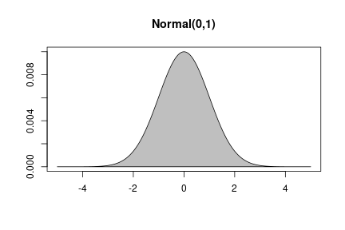

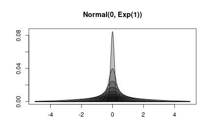

## Why use a scale mixture?

1. Lets the data choose the appropriate scale of variation.
2. Weakly encourages $\sigma$ to be small: so, as much variation as possible is explained by *signal* instead of *noise*.
3. Gets you a prior that is more peaked at zero and flatter otherwise.

# Application

## The plan

Fit a linear model to the `diabetes` dataset with:

1. no prior
2. horseshoe priors

## OLS in brms

```r
xy <- cbind(data.frame(y=diabetes$y), diabetes$x2)
names(xy) <- gsub("[:^]", "_", names(xy))

# ols
brms_ols <- brm(y ~ ., data=xy, family=gaussian(link='identity'))
```

## horseshoe in brms

```r
brms_hs <- brm(y ~ ., data=xy, family=gaussian(link='identity'),
               prior=c(set_prior(horseshoe(), class="b")))
# (khs <- brms::kfold(brms_hs, K=5))
```

## Crossvalidation error function

```r
brms_kfold <- function (K, models) {
    stopifnot(!is.null(names(models)))
    Kfold <- sample(rep(1:K, nrow(xy)/K))
    results <- data.frame(rep=1:K)
    for (j in seq_along(models)) {
        train <- test <- rep(NA, K)
        for (k in 1:K) {
            new_fit <- update(models[[j]], newdata=subset(xy, Kfold != k))
            train[k] <- sqrt(mean(resid(new_fit)[,"Estimate"]^2))
            test_y <- xy$y[Kfold == k]
            test[k] <- sqrt(mean(
                   (test_y - predict(new_fit, newdata=subset(xy, Kfold==k))[,"Estimate"])^2 ))
        }
        results[[paste0(names(models)[j], "_train")]] <- train
        results[[paste0(names(models)[j], "_test")]] <- test
    }
    return(results)
}
```

```r
brms_xvals <- brms_kfold(5, list('ols'=brms_ols, 'horseshoe'=brms_hs))
```

## Crossvalidation results

[figure not shown]

## Coefficients:

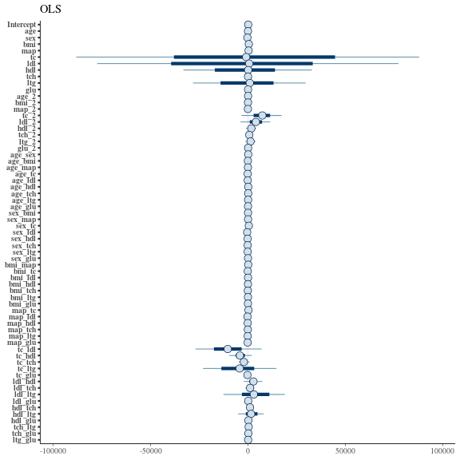

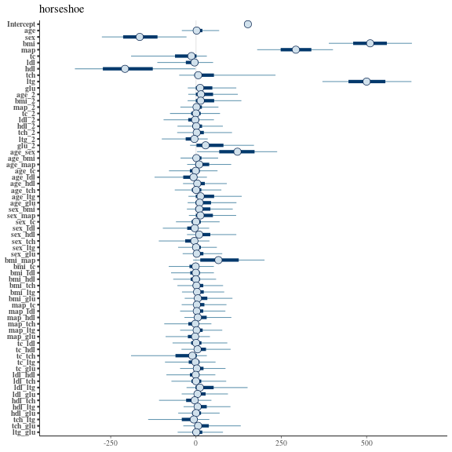

# Model fit

## What’s an appropriate noise distribution?

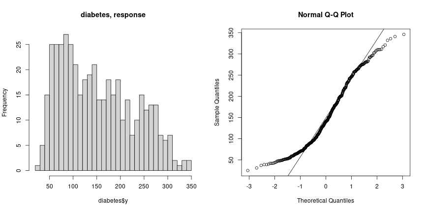

## Aside: quantile-quantile plots

The idea is to plot the *quantiles* of each distribution against each other.

If these are *datasets*, this means just plotting their *sorted values* against each other.

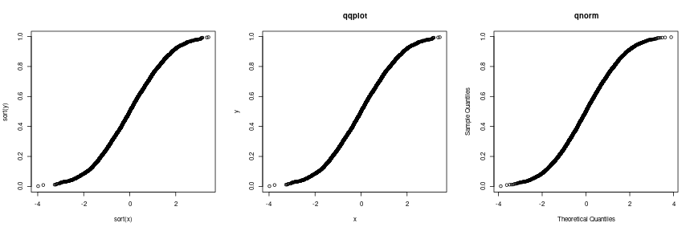

```r
x <- rnorm(1e4)
y <- rbeta(1e4, 2, 2)
plot(sort(x), sort(y)); qqplot(x, y, main="qqplot"); qqnorm(y, main="qnorm")
```

## Look at the residuals!

$$\begin{aligned}
y_i &= \sum_j \beta_j x_{ij} + \epsilon_i \\
\epsilon_i &\sim \Normal(0, \sigma^2) .
\end{aligned}$$

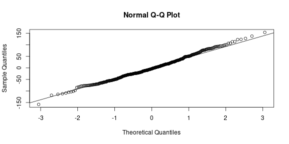

```r
ols_resids <- resid(lm(y ~ ., data=xy))
qqnorm(ols_resids)
qqline(ols_resids)
```

## Posterior preditive checks:

```r
pp_check(brms_hs)
```

```
## Using 10 posterior samples for ppc type 'dens_overlay' by default.
```

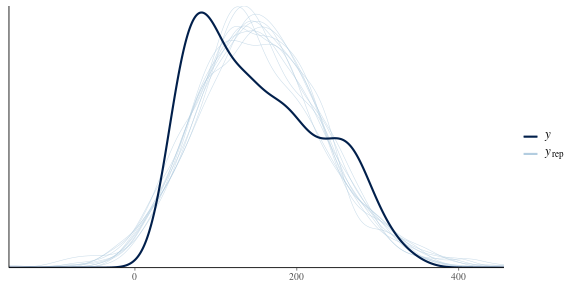

# More general crossvalidation

## `brms::kfold`

The `kfold` function will *automatically* do $k$-fold crossvalidation! For instance:

```r
(khs <- brms::kfold(brms_hs, K=5))
```

```
## Fitting model 1 out of 5
```

```
## Fitting model 2 out of 5
```

```
## Fitting model 3 out of 5
```

```
## Fitting model 4 out of 5
```

```
## Fitting model 5 out of 5
```

```
##
## Based on 5-fold cross-validation
##
##            Estimate   SE
## elpd_kfold  -2405.0 14.0
## p_kfold        33.2  3.6
## kfoldic      4810.0 28.0
```

`elpd` = “expected log posterior density”

[output not shown]